[figure not shown]

This notebook is part of a GitHub repository: https://github.com/pessini/avian-flu-wild-birds-ireland  
MIT Licensed  
Author: Leandro Pessini

# Analysis on Avian Influenza (Bird Flu) among Wild Birds in Ireland

[figure not shown]

# Contents:

# 1- Introduction

[figure not shown]

This analysis will investigate a dataset provided by Ireland's [Department of Agriculture, Food and the Marine](https://data.gov.ie/dataset/h5n1-wild-bird-species-identification) which contains the locations of bird species captured in Ireland from 1980-09-01 to 2020-01-27 and wild birds that are targeted for the H5N1 strain of avian flu.

Avian influenza or **"Bird Flu"** is a contagious and often fatal viral disease of birds. Wild birds, particularly wild migratory water birds are considered to be the main reservoir of avian influenza viruses. There is a constant risk of avian influenza being introduced into Ireland from wild birds particularly from November onwards each year as this is when migratory birds arrive and congregate on wetlands, mixing with resident species.

### Additional data

BirdWatch Ireland and Ordinance Survey Ireland

# 2- Data Storytelling

## Proportion of captured birds with avian flu

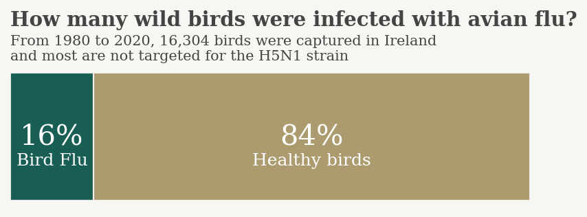

## Species

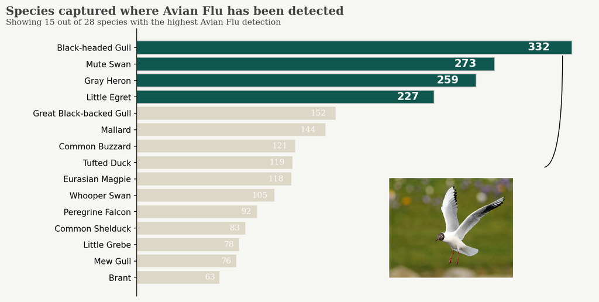

### Birds Species with more than 200 Bird Flu detections

- **Black-headed Gull**: 332 https://birdwatchireland.ie/birds/black-headed-gull/
- **Mute Swan**: 273 https://birdwatchireland.ie/birds/mute-swan/
- **Gray Heron**: 259 https://birdwatchireland.ie/birds/grey-heron/
- **Little Egret**: 227 https://birdwatchireland.ie/birds/little-egret/

## What locations have registered the highest number of wild birds with avian flu?

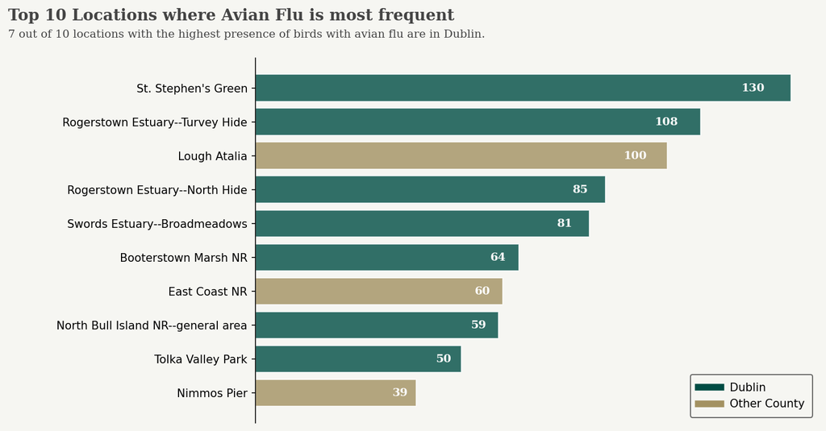

## In which months are birds with Bird Flu more frequent?

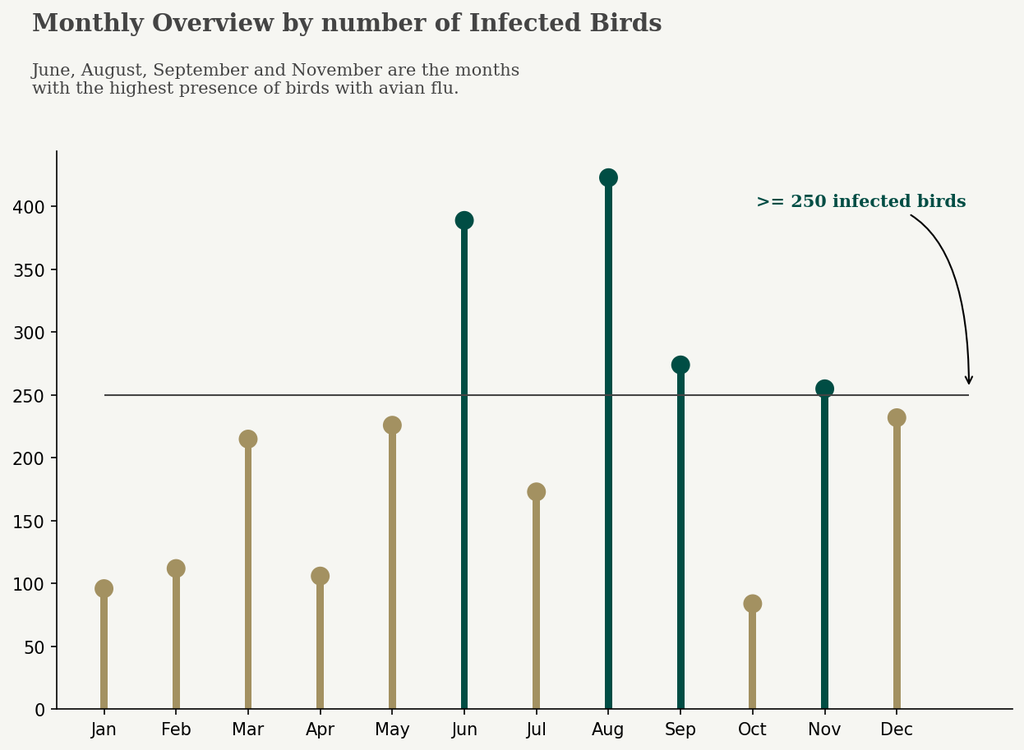

## Wild birds with avian flu have increased or have decreased in the past decade?

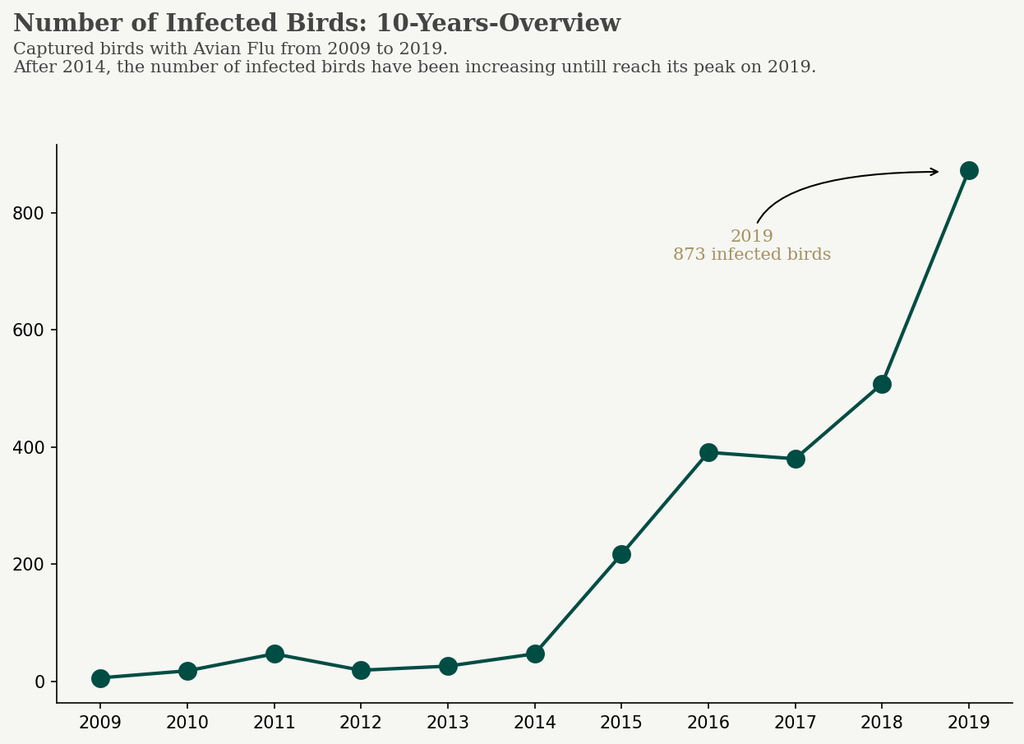

# 3- Geospatial data

## HeatMap representing how Avian Flu is geographically distributed

[interactive chart not shown]

## Historical spread of Bird Flu in Ireland

```
Dublin: 1176 - 48.55%
Not Dublin: 1246.0 - 51.45%
```

```
Python version: 3.8.5
```

```
Author: Leandro Pessini

folium    : 0.12.1
json      : 2.0.9
seaborn   : 0.11.1
PIL       : 8.2.0
pandas    : 1.1.3
geopandas : 0.9.0
numpy     : 1.20.2
matplotlib: 3.3.2
```

[figure not shown]

[GitHub repository](https://github.com/pessini/avian-flu-wild-birds-ireland)  
Author: Leandro Pessini